# VisiMod: Map Modeled Visibility Index Across Wildland Landscapes

Katherine Mistick 2023-09-25

- **Download lidar data to prepare for VisiMod workflow**
- **The VisiMod Workflow**
- **Using VisiMod() to generate an RGB VI map**

The VisiMod package was built to facilitate visibility analyses. It provides a suite of tools that allows users to build predictive models that can map visibility (in terms of visibility index (VI) where VI = (visible area)/(total area)) across entire landscapes. [Mistick et. al. 2023 (Using airborne lidar and machine learning to predict visibility across diverse vegetation and terrain conditions)](https://content.csbs.utah.edu/~pdennison/reprints/denn/2023_Mistick_etal_IJGIS.pdf)) is the original research that led to the development of VisiMod.

VisiMod is designed to be used in wildland (i.e. undeveloped) areas. It relies on a digital surface model (DSM) that is inclusive of vegetation. If VisiMod were deployed for developed areas any aboveground obstructions would be treated as vegetation. This is not recommended.

The VisiMod package can be installed by calling `devtools::install_github("kamistick/VisiMod")`in the RStudio console. To run the following examples the following packages must be loaded: `VisiMod`, `terra`, `leaflet`, `httr2`, `httr`, `lidR`, `future`, `ggplot2`

## **Download lidar data to prepare for VisiMod workflow**

VisiMod only requires users to provide a digital terrain model (DTM) and digital surface model (DSM) to run the full workflow. While fine-scale resolution DTMs are available to download (ex.), fine-scale DSMs most typically are derived directly from lidar. The example below walks a user through downloading and processing four USGS 3DEP lidar tiles for use in the VisiMod workflow.

For this example we’re going to look at a 4km<sup>2</sup> area in southern Utah, USA:

[interactive chart not shown]

We’ll use the National Map API, provided by the USGS, to access 3DEP lidar data. For more information on how to use the THM API, [click here](https://apps.nationalmap.gov/tnmaccess/#/). To interact with the TNM GUI and download data, [click here](https://apps.nationalmap.gov/downloader/).

### **Set Up Directories**

First, we will set up our directories. In this example the main directory `lidar_dir` is a folder with four subfolders: `noise`, `dtms`, `dsms`, and `out_files`. We will download, prepare, and generate new files in these directories throughout these examples. The code below will check if the subfolders in your directory exist, and create them if they do not.

```r
lidar_dir <- "/path/to/your/Data"
```

```r
for (folder in c("noise", "dtms", "dsms", "out_files")){
  if (!dir.exists(file.path(lidar_dir, folder))){
  dir.create(file.path(lidar_dir, folder))
  } else {
      print("Directory already exists.")
  }
}
```

### **Download lidar using The National Map API**

Next we will search for available lidar products within our bounding box:

```r
bounding_box <- "-113.796282,38.008962,-113.785245,38.018234"
product_format <- "LAS,LAZ"
url <- paste0("https://tnmaccess.nationalmap.gov/api/v1/products?bbox=", bounding_box, "&prodFormats=", product_format)
req <- request(url)
resp <- req %>% req_perform()
```

Next we’ll grab the download links for the LAZ point clouds, of which there are 4. We’ll also need the filenames so we can save each file.

```r
for (x in 1:length(resp_body_json(resp)[2]$items)){
  # get download link
  download_link <- resp_body_json(resp)[2]$items[[x]]$urls$LAZ

  #get file name without white spaces
  filename <- gsub(" ", "", resp_body_json(resp)[2]$items[[x]]$title)

  #use httr::GET() to download each laz tile
  print(paste0("Downloading ", filename))
  httr::GET(download_link, write_disk(paste0(lidar_dir, "/", filename, ".laz"), overwrite=TRUE))
}
```

```
## [1] "Downloading USGSLidarPointCloudUT_StatewideSouth_2020_A2012STH5410"
## [1] "Downloading USGSLidarPointCloudUT_StatewideSouth_2020_A2012STH5411"
## [1] "Downloading USGSLidarPointCloudUT_StatewideSouth_2020_A2012STH5510"
## [1] "Downloading USGSLidarPointCloudUT_StatewideSouth_2020_A2012STH5511"
```

### **Process lidar with lidR in R**

Next we’ll use the [lidR package](https://r-lidar.github.io/lidRbook/) to process our tiles into a DTM and DSM. First we will read the files in as a lascatalog, and plot them. It is recommended that you index your lidar tiles before proceeding using `lidR:::catalog_laxindex(cat)`. Indexing allows for faster processing and is especially advantageous when dealing with large LAScatalogs. For more on LAScatalogs check on this vignette: [LAScatalog formal class](https://cran.r-project.org/web/packages/lidR/vignettes/lidR-LAScatalog-class.html)

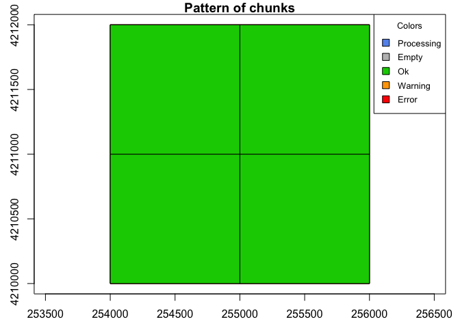

[output not shown]

```r
# read in files as a LAScatalog
cat <- readLAScatalog(lidar_dir)
lidR:::catalog_laxindex(cat)
```

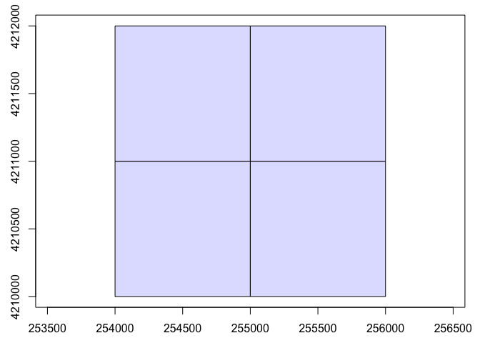

```r
plot(cat)
```

#### **Remove Noise**

First we’ll clean up the lidar data to remove any noise. This step can look very different depending on your lidar data. Some datasets are fairly clean to begin with, others may have extremely high or low noise flagged as classification 7 or 18. These points are removed by filtering. However, there may be certain high or low points that were not classified as noise, but should be. We run an additional noise filter and remove the noise flagged points a second time to ensure all extraneous points have been removed. If you have multiple cores available to work on, we suggest using them by implementing `plan(multisession, workers = 4L)` and `set_lidr_threads(4L)`, which would implement 4 cores for parallel processing.

```r
# set up parallel processing, if available
plan(multisession, workers = 4L)
set_lidr_threads(4L)
```

```
## This installation of lidR has not been compiled with OpenMP support
```

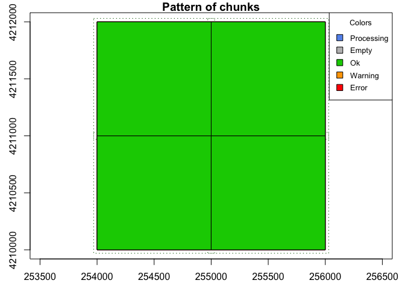

```
##   |                                                                                                            |                                                                                                    |   0%  |                                                                            …

## class       : LAScatalog (v1.4 format 6)
## extent      : 254000, 256000, 4210000, 4212000 (xmin, xmax, ymin, ymax)
## coord. ref. : NAD83(2011) / UTM zone 12N + NAVD88 height - Geoid12B (Metres)
## area        : 4 km²
## points      : 21.68 million points
## density     : 5.4 points/m²
## density     : 4.5 pulses/m²
## num. files  : 4
```

```r
# define directoy where clean laz files will be written
clean_dir <- file.path(lidar_dir, "noise")

# filter points already classified as noise or withheld
opt_filter(cat) <- "-drop_class 7 18 -drop_withheld"

# perform an additional noise filter
opt_output_files(cat) <- file.path(clean_dir, "{ORIGINALFILENAME}")
opt_laz_compression(cat) <- TRUE
classify_noise(cat, sor())
```

```r
# read back in cleaned catalog and filter points classified as noise or withheld
cat_clean <- readLAScatalog(clean_dir)
opt_filter(cat_clean) <- "-drop_class 7 18 -drop_withheld"
```

#### **Generate Rasters**

Next we’ll generate our 1 meter DTM and DSM using `rasterize_terrain()` and `rasterize_canopy()`. This step will genereate and save a raster (in TIF format) in the `lidar_dir` directory (in this example they are saved in subfolders `dtms` and `dsms`).

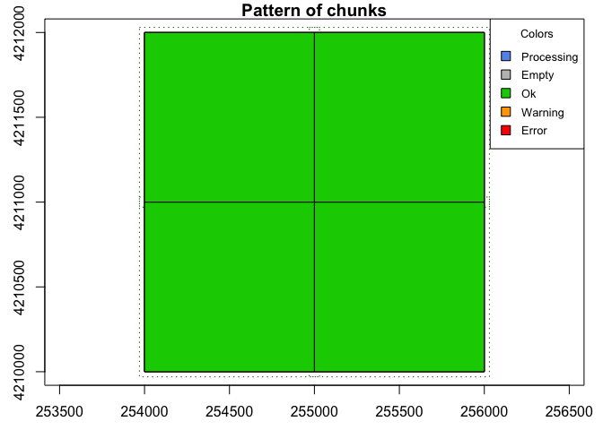

```
##   |                                                                                                            |                                                                                                    |   0%  |                                                                            …

## class       : SpatRaster
## dimensions  : 2000, 2000, 1  (nrow, ncol, nlyr)
## resolution  : 1, 1  (x, y)
## extent      : 254000, 256000, 4210000, 4212000  (xmin, xmax, ymin, ymax)
## coord. ref. : NAD83(2011) / UTM zone 12N (EPSG:6341)
## source      : rasterize_terrain.vrt
## name        :       Z
## min value   : 1851.18
## max value   : 2045.34
```

```r
# new directories
dtm_dir <- file.path(lidar_dir, "dtms")
dsm_dir <- file.path(lidar_dir, "dsms")

# generate dtms
opt_output_files(cat_clean) <- file.path(dtm_dir, "dtm_{XLEFT}_{YBOTTOM}")
rasterize_terrain(cat_clean, res= 1, algorithm = tin(), overwrite = TRUE)
```

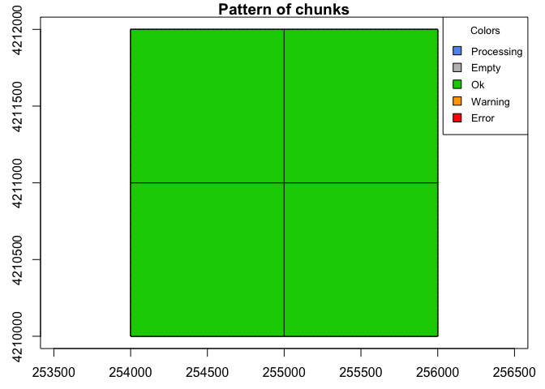

```
##   |                                                                                                            |                                                                                                    |   0%  |                                                                            …

## class       : SpatRaster
## dimensions  : 2000, 2000, 1  (nrow, ncol, nlyr)
## resolution  : 1, 1  (x, y)
## extent      : 254000, 256000, 4210000, 4212000  (xmin, xmax, ymin, ymax)
## coord. ref. : NAD83(2011) / UTM zone 12N (EPSG:6341)
## source      : rasterize_canopy.vrt
## name        :        Z
## min value   : 1851.396
## max value   : 2047.705
```

```r
# generate dsms
opt_output_files(cat_clean) <- file.path(dsm_dir, "dsm_{XLEFT}_{YBOTTOM}")
rasterize_canopy(cat_clean, res = 1, dsmtin(), overwrite= TRUE)
```

Next we have to mosaic all four DTM tiles together to get a continuous DTM for the study area. First we’ll read in each individual DTM raster using `rast()`, then we’ll mosaic them together using `mosaic()`. If you’d like to save your study-area-wide DTM use `writeRaster()`.

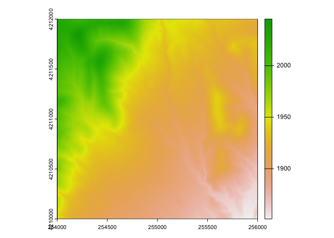

```r
dtm_dir <- file.path(lidar_dir, "dtms")
dtm_tiles <- list.files(dtm_dir, pattern = "*.tif", full.names = T)
dtm_rasts <- lapply(dtm_tiles, rast)
dtm_sprc <- sprc(dtm_rasts)
dtm <- mosaic(dtm_sprc)
plot(dtm)
```

```r
writeRaster(dtm, file.path(lidar_dir, "out_files", "dtm.tif"), overwrite=TRUE)
```

Next we’ll repeat that process for the DSMs

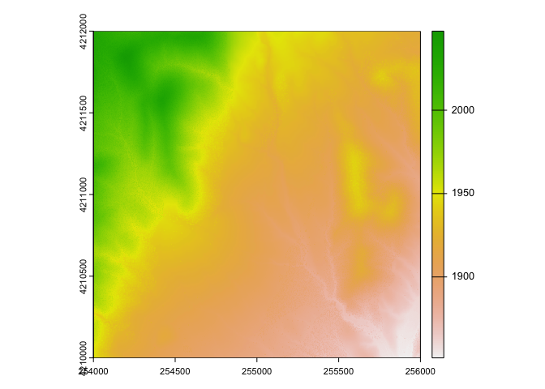

```r
dsm_dir <- file.path(lidar_dir, "dsms")
dsm_tiles <- list.files(dsm_dir, pattern = "*.tif", full.names = T)
dsm_rasts <- lapply(dsm_tiles, rast)
dsm_sprc <- sprc(dsm_rasts)
dsm <- mosaic(dsm_sprc)
plot(dsm)
```

```r
writeRaster(dsm, file.path(lidar_dir, "out_files", "dsm.tif"), overwrite=TRUE)
```

Those look very similar, so to check that our DSM is inclusive of vegetation, we can subtract the DTM from the DSM to just look at the canopy height:

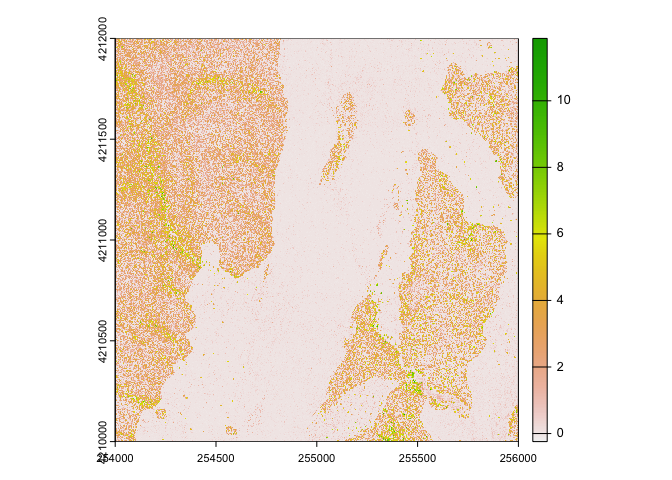

```r
chm <- dsm-dtm
plot(chm)
```

## **The VisiMod Workflow**

### **1 Prepare Digital Elevation Models**

The first step in the VisiMod workflow is to run your DTM and DSM through the `prep_dems()` function. This function checks if the two input SpatRasters are spatially aligned, in appropriate projected coordinate systems (where linear units are measured in meters), and if any interior NA values need to be filled. The function prints useful update messages, which are suppressed here, which let users know which, if any, requirements are not met.

In this example, the DSM does have some interior NAs (11, to be exact), so the `prep_dems()` function will let users know that the `"dtm and dsm are spatially aligned"`, that the `"dtm and dsm have suitable coordinate systems"`, and that the `"dsm has 11 NAs. Removing..."` (among other printed messages). Knowing that the DSM has interior NAs means we must use the output DSM from the `prep_dems()` as we continue through the VisiMod workflow, because interior NA values are problematic for subsequent functions.

```r
dtm <- rast(file.path(lidar_dir, "out_files", "dtm.tif"))
dsm <- rast(file.path(lidar_dir, "out_files", "dsm.tif"))

pdems <- prep_dems(dtm, dsm, file.path(lidar_dir, "out_files","dtm_filled.tif"), file.path(lidar_dir, "out_files","dsm_filled.tif"))
```

### **2 Generate Points**

The second step in the VisiMod workflow is to generate x, y locations to be used as training and validation points for building one or more VI models. The user-defined number of points are randomly distributed within the study area at an appropriate distance from the study area boundary. This distance is controlled by the `max_vi_rad` parameter which indicates the maximum distance to which VI will be calculated (and therefore modeled). As `max_vi_rad` increases, processing time will increase exponentially.

```r
gp <- gen_pts(dtm, pdems$dsm, 200, 250)
head(gp)
```

|  | x | y |
| --- | --- | --- |
| 1 | 255579.2 | 4210426 |
| 2 | 254660.0 | 4211640 |
| 3 | 254624.1 | 4211344 |
| 4 | 254783.3 | 4211712 |
| 5 | 255531.7 | 4210405 |
| 6 | 255530.8 | 4211037 |

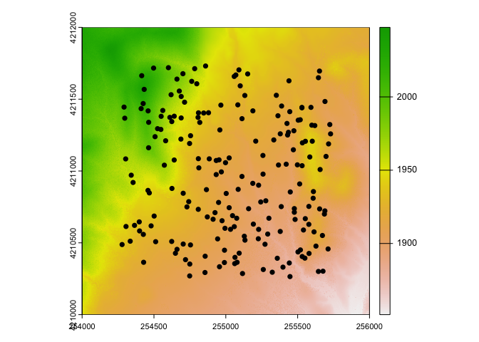

```r
v <- vect(cbind(gp$x, gp$y))
plot(dsm)
plot(v, add=TRUE)
```

### **3 Calculate VI**

The next step in the VisiMod workflow is `calc_vi()` which calculates VI at each point location. VI represents the proportion of area visible from a given point relative to the total area within a viewing distance of interest, ranging from 0 (no visibility) to 1 (complete visibility). This function can be used to calculate omnidirectional VI (in 360 degrees surrounding each point) or directional VI (within a wedge of specified field of view, and in a specified view-direction (azimuth)).

For this example we will look at omnidirectional VI and set `vi_type` equal to `omnidir`. We will look at multiple distances, not to exceed the original `max_vi_rad` set in `gen_pts()`. We will also set `cores = 4` to run this using just 4 cores.

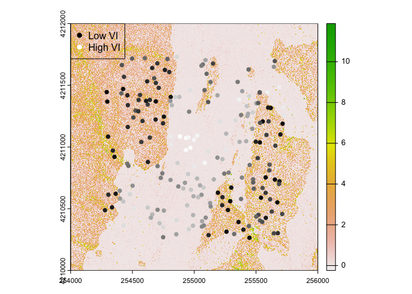

```r
cv <- calc_vi(dtm, pdems$dsm, gp, "omnidir", c(125, 250), cores = 4)

# plot points on top of canopy height, color coded by VI at a 125 m radius
v <- vect(cbind(cv$x, cv$y))    #vectorize the output data.frame
df <- cv    # grab a copy of cv so we don't add any unnecessary columns to our working data.frame

pal = colorRampPalette(c("black", "white"))
df$order = findInterval(df$vi_125, sort(df$vi_125))
plot(pdems$dsm-dtm, legend= TRUE)
plot(v, add=TRUE, col = pal(nrow(df))[df$order])
legend(x = 254000, y = 4212000,
       col = c("black", "white"), pch = c(19,19),
       legend = c('Low VI', 'High VI'), bg = "#00000000")
```

### **4 Generate Model Predictors**

Following the calculation of VI at each point, next in the VisiMod workflow is the generation of predictors at each point. The `gen_preds()` function generates and extracts a suite of visibility predictor pixel values at each input point location. The vi_type should match that which was used for `calc_vi()`. In this case we will continue with `"omnidir"` and use our output dataframe from `calc_vi()` as the input points. Since our input DTM and DSM are at a 1 m spatial resolution we set our aggregation factor (`agg_fact`) equal to 10L. This means the predictor rasters will be generated at a spatial resolution 10x the input (in this case, 10 m). We recommend using this combination of spatial resolutions, but other combinations can be explored by changing the `agg_fact` parameter or the resolution of data used.

More details on gen_preds() can be found in the function documentation. For more details see Table 1 in [Mistick et. al. 2023]((https://content.csbs.utah.edu/~pdennison/reprints/denn/2023_Mistick_etal_IJGIS.pdf). Only local and focal variables are included in VisiMod.

**NOTE** The maximum radius we are looking to in this example is 250 m. Our full study area is 2000 m x 2000 m therefore the area in which our points were randomly sampled is 1500 m x 1500 m. Some points may lie exactly 250 m from the study area boundary, which is **less than** the largest radius to which focal predictors are generated. In this case focal predictors out to 32 pixels (or 320 m) will return NA values for points that are < 32 pixels (or 320 m) from the study area edge.

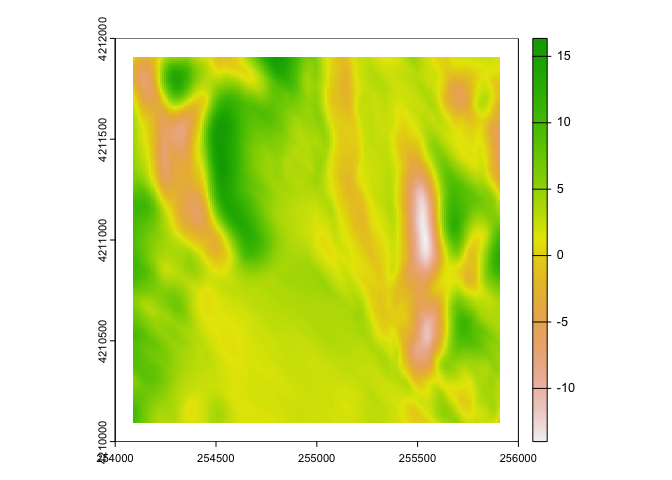

```r
preds <- gen_preds(dtm, pdems$dsm, cv, "omnidir", agg_fact = 10L, save_dir = file.path(lidar_dir, "out_files"))

# plot an example predictor raster
plot(preds$pred_rast[["slope_aspect_sin_mean_8"]])
```

### **5 Build Random Forest Model**

Now that we have points with VI and predictor values we can move to the next step in VisiMod which is to build a predictive model using `mod_vi()`. This function will build a random forest model to predict VI based on the predictor values at each point. We will use the output data.frame from `gen_preds()` because it contains all our points inclusive of VI and predictor values.

We will set `cross_validate = TRUE` and `tune = FALSE`. These parameters can be toggled depending on the user’s research goal. In this case we’d like to perform a 4-fold spatial cross-validation procedure to assess model performance, but don’t want the hyperparameter tuning to slow down our processing significantly.

Since we have calculated VI at two different radii we will call `mod_vi()` twice, once for each radii.

```r
mod125 <- mod_vi(preds$pred_pts, 125, cross_validate = TRUE, tune = FALSE, num_cores = 4)
head(mod125$perf_mets)
```

```
## $r2
## [1] 0.8380921
##
## $rmse
## [1] 0.066016
##
## $nrmse
## [1] 0.122255
```

```r
mod250<- mod_vi(preds$pred_pts, 250, cross_validate = TRUE, tune = FALSE, num_cores = 4)
```

[figure not shown]

```r
head(mod250$perf_mets)
```

```
## $r2
## [1] 0.7455943
##
## $rmse
## [1] 0.05060788
##
## $nrmse
## [1] 0.1175507
```

### **6 Map VI**

The final step in the VisiMod workflow is to map VI across the entire study area, using the random forest model built in `mod_vi()` and the predictor raster stack generated with `gen_preds()`.

We will run this function twice, once per radius, to map VI at both our radii (125 m and 250 m).

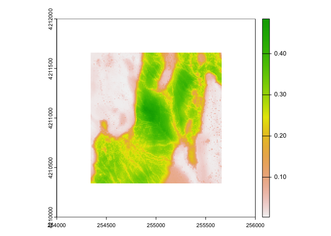

```r
map125 <- map_vi(mod125$ranger_mod, preds$pred_rast, 4, FALSE)
plot(map125)

map250 <- map_vi(mod250$ranger_mod, preds$pred_rast, 4, FALSE)
plot(map125)
```

[output not shown]

## **Using VisiMod() to generate an RGB VI map**

### **Run the Function**

Now that we have prepared our DTM and DSM we are ready to run some functions from VisiMod. We’ll start with the all-encompassing `VisiMod()` function. This function runs through the entire VisiMod workflow and returns a list of rasters with mapped VI values. First we have to define our input rasters, then we run `VisiMod()`. In this example we are going to generate three VI maps, at azimuths of 0 degrees (looking north), 120 degrees (looking southeast), and 240 degrees (looking southwest) each with a field of view of 120 degrees.

Running this example with 4 cores resulted in a total run time of 3 minutes and 25 seconds. Many messages will print indicating progress. When working with larger datasets it is not unusual for `calc_vi()` and `gen_preds()` to perform slowly. Notably, the step that generates predictors at 32 pixel radii tends to be slow, if it appears frozen at this step please be patient.

```r
# define your input params
dtm <- rast(file.path(lidar_dir, "out_files","dtm.tif"))
dsm <- rast(file.path(lidar_dir, "out_files","dsm.tif"))

visi_out <- VisiMod(dtm=dtm, dsm=dsm,
                    num_pts = 200,dist =125,
                    vi_type = "directional_single",
                    vi_fov = 120, vi_azi = c(0,120,240),
                    save_dir =paste0(lidar_dir, "/out_files"), cores = 4)
```

To visualize the area in which VI and predictors are being generated, we can use the wedge() function to draw wedges. In the example below three wedges will be drawn, one for each azimuth in our previous call to VisiMod() (0, 120, 240). We will color the wedges according to the RGB channel with which they will be visualized in the next step.

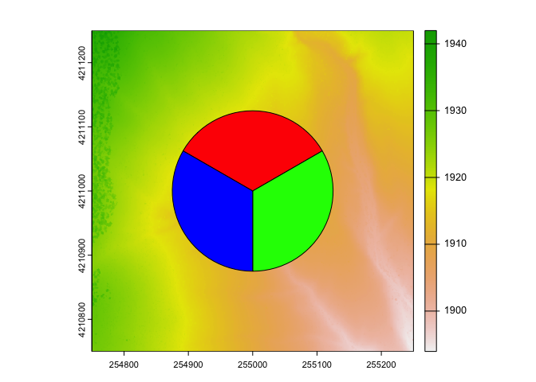

```r
# plot the dsm as our basemap (zoom in a bit)
plot(dsm, ext = ext(dsm)-750)

# use the midpoint as the point from which our wedge will be drawn
x <- (ext(dtm)[2]+ext(dtm)[1])/2
y <- (ext(dtm)[4]+ext(dtm)[3])/2

w <- wedge(x = x[[1]], y = y[[1]], 125, 0, 120)
plot(w, col = "red", add=TRUE)

w <- wedge(x = x[[1]], y = y[[1]], 125, 120, 120)
plot(w, col = "green", add=TRUE)

w <- wedge(x = x[[1]], y = y[[1]], 125, 240, 120)
plot(w, col = "blue", add=TRUE)
```

### **Using plotRGB() to plot VI**

The first option for plotting VI is using the plotRGB() function from the terra library. This is an easy way to plot 3 band rasters

Since `VisiMod()` returns a list of three single-band rasters, we must combine them into a multiband raster before we can plot an RGB map. We apply a scale of 1 to tell the `plotRGB()` function that our values range from 0-1 (the default assumes 0-255). We have also applied a stretch to the plot, since VI values tend to not cover the full 0-1 range (100% visibiliy, in this study area, is rare), we stretch the values so the pattern of colors is more easily discerned. The 32 pixel buffer is also left in place so users can see that predictions are returned with buffer equal to the largest focal predictor radius considered.

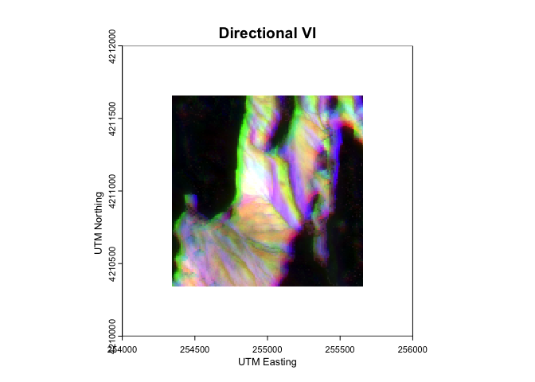

```r
vi <- c(visi_out[[1]],visi_out[[2]],visi_out[[3]])
plotRGB(vi, r=1,g=2,b=3, scale = 1, stretch="lin", axes = TRUE, mar = c(3,3), xlab = "UTM Easting", ylab = "UTM Northing", main = "Directional VI")
```

### **Using ggplot2 to plot RGB VI map**

`ggplot2` is a powerful and popular library for creating graphics. While not built explicitly to plot raster data, it can easily plot rasters that have been converted to a data.frame. For smaller datasets this option is beneficial in that it allows for more control over the plot, and users may already be more familiar with this plotting library. The example below excludes the original border, unlike the `plotRGB()` example. This example also does not apply a stretch to the values, meaning the color ramp is not stretch from 0 to 1 but reflects 0 to the maximum VI for that color channel.

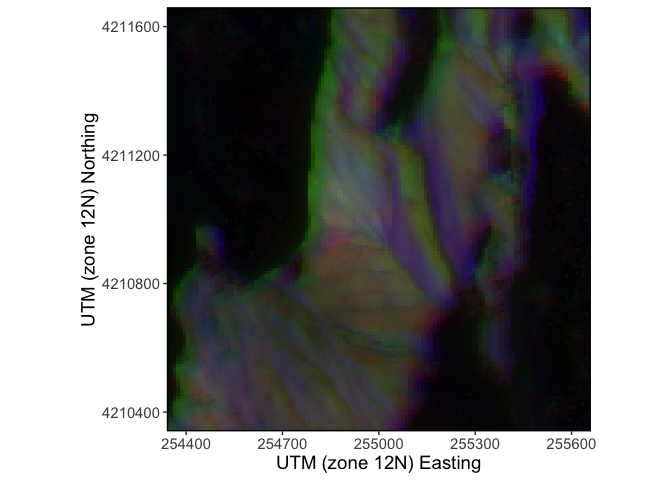

```r
vi <- c(visi_out[[1]],visi_out[[2]],visi_out[[3]])
vi_df <- as.data.frame(vi, xy=TRUE, na.rm)
vi_df <- na.omit(vi_df)
p <- ggplot(data=vi_df, aes(x=x,y=y)) +
  geom_raster(fill = rgb(r = vi_df$vi_d125_f120_a0,
                         g=vi_df$vi_d125_f120_a120,
                         b=vi_df$vi_d125_f120_a240, maxColorValue =1)) +
  ylab("UTM (zone 12N) Northing")+
  xlab("UTM (zone 12N) Easting") +
  scale_x_continuous(expand = expansion(c(0,0)))+
  scale_y_continuous(expand = expansion(c(0,0)))+
  theme(panel.background = element_rect(color = NA, fill = NA),
        panel.border = element_rect(colour = "black", fill=NA, linewidth=1),
        text = element_text(size = 14),
        aspect.ratio = 1) +
  guides(fill = guide_legend(override.aes = list(size = 5)))+
  labs(fill = "Radius (m)", size = "Field of View \n(degrees)")
p
```